# LiveScene

# Who we are

[figure not shown]

We are 5 students entrepreneurs from SKEMA Business School in Lille We are interested by culture and entrepreneurship Two of us have an engineering background and coding competences in R Markdown and JavaScript

We are powered by many partners

### SKEMA Global Lab in DATA and IA (based in Montreal)

### ENACTUS Hauts-de-France and ENACTUS France

### PEPITE networks

[figure not shown]

# What we do

### Our business wants to modify the way people consume art and culture.

Our project is to create a platform that allows users to order live shows “spectacles vivants”: theatre, opera, shows, festivals, concerts, “cinema d’auteur” thanks to a subscription that makes a price per seat very much cheaper thanks to partnerships with cultural institutions…

The platform looks like a Netflix one, based on subscription by every people who wants to go and see several shows every month in his/ her town.

### The subscription wants to be affordable and flexible.

### The offer is personalized and original.

The idea is starting to be experimented in Lille which benefits from a very dynamic cultural life. Next step : development in Paris, European Capitals and other towns (France, England, Spain, Germany…)

## Mission.

To modify the way people consume live shows and digitalize it.

## Description of Product and Service.

A platform which gives free information of what happen in terms of culture and shows in your town but where you have to pay to book places by a subscription.

Algorithm for a personalized offer depending on what you like / have seen before

Negotiation of contracts with cultural partners to have a quota of places in every show for the users of the platform (App + website)

## Value proposition to Customer

- Pay less for live shows (that are quite expensive)
- Cultural partners sell all their tickets, and before but for a little bit less expensive - All the info + booking on one only platform

## Innovative dimensions of the product or service.

- Modification of how people consume culture
- democratize culture
- find a younger public

## Target market(s).

- BtoB between cultural partners and our platform (Comités d’entreprises, agents touristiques, partenaires publics).
- BtoC : medium (from 1 show seen by month) and big consumers of shows and culture from 20 to 50 years old

# Our Team

[figure not shown]

# What our platform will look like

Our platform is currently developed thanks to our founder’s knowledge in R coding, and two external partners. Nevertheless, we are still searching for a full time founder developer inside the team

[figure not shown]

# Our business model

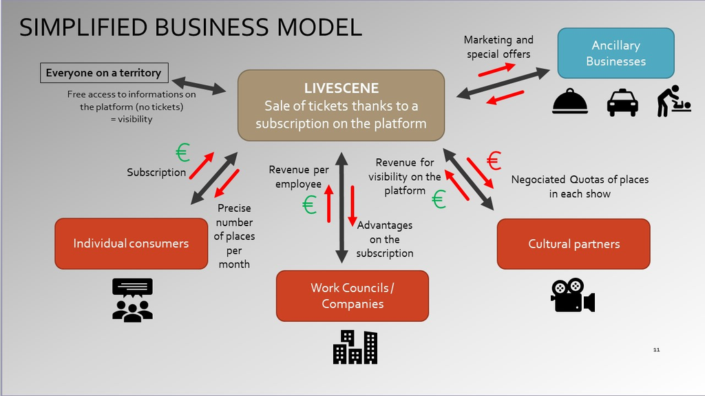

# Our stage reached

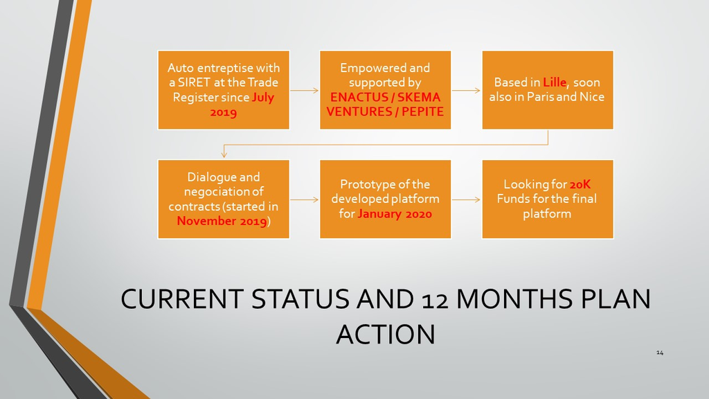

# Contact

- Team. livescenefrance@gmail.com
- Founder. maxence.padua@skema.edu

### Youtube presentation.

- LiveScene for Partners

[click here](https://www.youtube.com/watch?v=_EePVDLG_jo)

powered by skemagloballab.io

2020-01-09